# COS-D419 Factor Analysis and Structural Equation Models 2023, Assignment 5

### Visualize the final baseline models for each group

At this stage, the elm and sec models have some differences.

### Visualization of the final Baseline Model

(Script again from Lashini’s work!!)

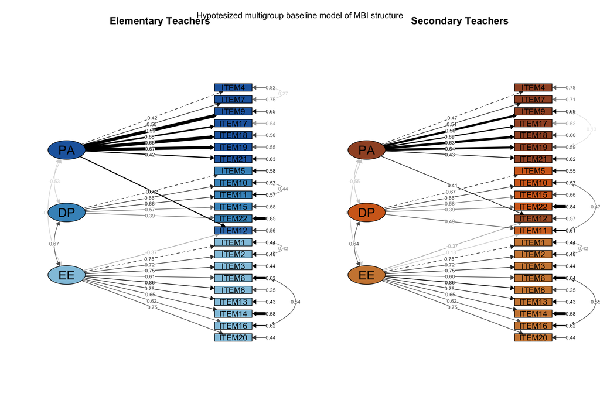

```r
library(semPlot)
library(patchwork)

par(mfrow=c(1,2))

semPaths(CFA_Ele3, "par", "std", style = "lisrel", layout = "tree", groups = "lat", color = c("#92C5DE","#4393C3", "#2166AC" ), posCol= c("black"), negCol = c("black"),
intercepts = FALSE, curvature = 1, residuals = TRUE, thresholds = FALSE, reorder = TRUE,
rotation = 2,
latents = c("EE","DP", "PA"),
sizeLat = 10, sizeLat2 = 5,
manifests = rev(colnames(MBIelm)),
sizeMan = 10, sizeMan2 = 2,
title = T)
title("Elementary Teachers")

semPaths(CFA_Sec4, "par", "std", style = "lisrel", layout = "tree", groups = "lat", color = c("#CD853F","#D2691E", "#A0522D" ), posCol= c("black"), negCol = c("black"),
intercepts = FALSE, curvature = 1, residuals = TRUE, thresholds = FALSE, reorder = TRUE,
rotation = 2,
latents = c("EE","DP", "PA"),
sizeLat = 10, sizeLat2 = 5,
manifests = rev(colnames(MBIelm)),
sizeMan = 10, sizeMan2 = 2,
title = T)
title("Secondary Teachers")

mtext("Hypotesized multigroup baseline model of MBI structure",
side = 3,
line = - 2,
outer = TRUE)
```

## Exercise 5.2:

“**Now we are getting to the point of this Assignment: testing the invariance.** See slide #14.

*Note:* To continue you have to combine the two data sets into one data set, so that it includes a variable for identifying the two groups.

As soon as you have the new data, go ahead and specify the *common baseline (configural) model*, and then begin the **invariance testing** by estimating that configural model and studying its output. See below! A lot of ready R code given! :)”

### Combine the data sets and establish the group variable accordingly

```r
# There are many ways to do this in R, this is just one possibility:
# (you may well use your own way to achieve a similar result!)
# (merge() comes from the base R, it has a handy argument `group`)

MBIelmsec <- merge(data.frame(MBIelm, group = "elementary"),
                   data.frame(MBIsec, group = "secondary"),
                   all = TRUE, sort = FALSE)

# quickly check that the new group variable includes the specified values:
head(MBIelmsec[, 21:23])
```

|  | ITEM21 | ITEM22 | group |
| --- | --- | --- | --- |
| 1 | 5 | 0 | elementary |
| 2 | 3 | 2 | elementary |
| 3 | 3 | 2 | elementary |
| 4 | 6 | 0 | elementary |
| 5 | 5 | 1 | elementary |
| 6 | 5 | 0 | elementary |

```r
tail(MBIelmsec[, 21:23])
```

|  | ITEM21 | ITEM22 | group |
| --- | --- | --- | --- |
| 1267 | 4 | 5 | secondary |
| 1268 | 5 | 0 | secondary |
| 1269 | 3 | 1 | secondary |
| 1270 | 6 | 0 | secondary |
| 1271 | 4 | 3 | secondary |
| 1272 | 5 | 2 | secondary |

```r
# good - now we can identify the groups from the combined data, too!
```

### Configural model (common baseline model for both groups simultaneously)

To get you going, I give you the complete, commented R code for the configural model below (see also https://lavaan.ugent.be/tutorial/syntax2.html).

**NOTE:** No equality constraints are imposed (see the end of my slide #18). Not yet! :)

This is the default in lavaan (and as you will see, everything is much simpler than in Mplus).

You should have **401 degrees of freedom** when fitting the multigroup version of the baseline models for the two teacher groups. Please check that you get it right before proceeding forward!

```r
INV1model <- '
# CFA model for the burnout, the configural model:
#
# EE: EmotionalExhaustion
# DP: Depersonalization
# PA: PersonalAccomplishment
#
# The ones (1s) can be written explicitly (the default is the 1st one of each set):
# (this is "nice to know": would be easy to change the fixed item(s), if needed)

    EE =~ 1*ITEM1 + ITEM2 + ITEM3 + ITEM6 + ITEM8 + ITEM13 + ITEM14 + ITEM16 + ITEM20
    DP =~ 1*ITEM5 + ITEM10 + ITEM11 + ITEM15 + ITEM22
    PA =~ 1*ITEM4 + ITEM7 + ITEM9 + ITEM12 + ITEM17 + ITEM18 + ITEM19 + ITEM21

# Common modifications (from baseline models built above)
    EE =~ ITEM12 # common cross-loading
 ITEM1 ~~ ITEM2  # common residual covariances (3)
 ITEM6 ~~ ITEM16
ITEM10 ~~ ITEM11

# Group-specific parameters for elementary teachers:
 ITEM4 ~~ c(NA, 0)*ITEM7  # specific residual covariance

# Group-specific parameters for secondary teachers:
    EE =~ c(0, NA)*ITEM11 # specific cross-loading
 ITEM9 ~~ c(0, NA)*ITEM19 # specific residual covariance
'
```

The configural model (the common baseline model for both groups) can now be estimated:

(Again, I am giving you more R code to keep you on the track.) :) You may, of course, always edit my code and add your own!

```r
# From now on, we need the group argument in the cfa() function:
INV1fit <- cfa(INV1model, data = MBIelmsec, estimator = "MLM", group = "group")

# Numerical summary of the model (yes, it is getting longer...)
summary(INV1fit, fit.measures = TRUE, standardized = TRUE)
```

```
## lavaan 0.6.13 ended normally after 90 iterations
##
##   Estimator                                         ML
##   Optimization method                           NLMINB
##   Number of model parameters                       149
##
##   Number of observations per group:
##     elementary                                     580
##     secondary                                      692
##
## Model Test User Model:
##                                               Standard      Scaled
##   Test Statistic                              1189.811     939.696
##   Degrees of freedom                               401         401
##   P-value (Chi-square)                           0.000       0.000
##   Scaling correction factor                                  1.266
##     Satorra-Bentler correction
##   Test statistic for each group:
##     elementary                                 545.846     431.102
##     secondary                                  643.964     508.594
##
## Model Test Baseline Model:
##
##   Test statistic                             12040.836    9261.794
##   Degrees of freedom                               462         462
##   P-value                                        0.000       0.000
##   Scaling correction factor                                  1.300
##
## User Model versus Baseline Model:
##
##   Comparative Fit Index (CFI)                    0.932       0.939
##   Tucker-Lewis Index (TLI)                       0.922       0.929
##
##   Robust Comparative Fit Index (CFI)                         0.940
##   Robust Tucker-Lewis Index (TLI)                            0.931
##
## Loglikelihood and Information Criteria:
##
##   Loglikelihood user model (H0)             -43942.218  -43942.218
##   Loglikelihood unrestricted model (H1)     -43347.312  -43347.312
```

[output cut: 229 more lines]

```
##    .ITEM10            1.540    0.130   11.820    0.000    1.540    0.629
##    .ITEM11            1.640    0.129   12.662    0.000    1.640    0.679
##    .ITEM15            1.177    0.136    8.659    0.000    1.177    0.586
##    .ITEM22            1.861    0.136   13.729    0.000    1.861    0.726
##    .ITEM4             1.049    0.110    9.523    0.000    1.049    0.864
##    .ITEM7             0.874    0.071   12.341    0.000    0.874    0.677
##    .ITEM9             1.366    0.129   10.558    0.000    1.366    0.613
##    .ITEM12            0.997    0.082   12.144    0.000    0.997    0.556
##    .ITEM17            0.611    0.072    8.530    0.000    0.611    0.660
##    .ITEM18            0.672    0.075    8.909    0.000    0.672    0.490
##    .ITEM19            0.979    0.088   11.153    0.000    0.979    0.579
##    .ITEM21            1.862    0.123   15.165    0.000    1.862    0.820
##     EE                1.265    0.103   12.306    0.000    1.000    1.000
##     DP                0.846    0.137    6.195    0.000    1.000    1.000
##     PA                0.166    0.040    4.133    0.000    1.000    1.000
```

Study the output. Then, you will finally be ready for the point: **invariance testing** phase.

*(Luckily it will all be quite much simpler than with Mplus! But there are many phases.)*

Your task is to proceed *carefully* with the measurement model modifications for two TASKS:

**TASK 1) Factor loadings**

“Constraining groups of parameters to be equal across groups: Although providing identical labels is a very flexible method to specify equality constraints for a few parameters, there is a more convenient way to impose equality constraints on a whole set of parameters (for example: all factor loadings, or all intercepts). We call these type of constraints group equality constraints and they can be specified by the argument group.equal in the fitting function. For example, to constrain (all) the factor loadings to be equal across groups, you can proceed as follows:

HS.model <- ’ visual =~ x1 + x2 + x3 textual =~ x4 + x5 + x6 speed =~ x7 + x8 + x9 ’

fit <- cfa(HS.model, data = HolzingerSwineford1939, group = “school”, group.equal = c(“loadings”))

summary(fit)

If you omit the group.equal argument, all parameters are freely estimated in each group (but the model structure is the same).

```r
# take a look at this web page: https://lavaan.ugent.be/tutorial/groups.html
# (see esp. under the heading "Constraining groups of parameters to be equal across groups")

# TASK 1) begins here!
# ####################
# to constrain the 20 common factor loadings equal,
# simply use `group.equal` in cfa() for "loadings",
# and
# to keep the one specific cross-loading ("EE =~ ITEM11") free,
# simply use `group.partial` in cfa() for that cross-loading:

INV2fit <- cfa(INV1model,
               data = MBIelmsec,
               estimator = "MLM",
               group = "group",
               group.equal = c("loadings"),
               group.partial = c("EE =~ ITEM11")
               )


# Study the output carefully to see the results of these simple operations.
#
# Write a short note of what you see! This is always recommended, to make
# it easier for me, for others and yourself to follow your steps afterwards.
#
# (compare with the tricky Mplus procedure on slides #19-#21... ugh...) 8~)

summary(INV2fit, fit.measures = TRUE, standardized = TRUE)
```

```
## lavaan 0.6.13 ended normally after 68 iterations
##
##   Estimator                                         ML
##   Optimization method                           NLMINB
##   Number of model parameters                       149
##   Number of equality constraints                    20
##
##   Number of observations per group:
##     elementary                                     580
##     secondary                                      692
##
## Model Test User Model:
##                                               Standard      Scaled
##   Test Statistic                              1257.662     995.433
##   Degrees of freedom                               421         421
##   P-value (Chi-square)                           0.000       0.000
##   Scaling correction factor                                  1.263
##     Satorra-Bentler correction
##   Test statistic for each group:
##     elementary                                 576.993     456.687
##     secondary                                  680.669     538.746
##
## Model Test Baseline Model:
##
##   Test statistic                             12040.836    9261.794
##   Degrees of freedom                               462         462
##   P-value                                        0.000       0.000
##   Scaling correction factor                                  1.300
##
## User Model versus Baseline Model:
##
##   Comparative Fit Index (CFI)                    0.928       0.935
##   Tucker-Lewis Index (TLI)                       0.921       0.928
##
##   Robust Comparative Fit Index (CFI)                         0.937
##   Robust Tucker-Lewis Index (TLI)                            0.930
##
## Loglikelihood and Information Criteria:
##
##   Loglikelihood user model (H0)             -43976.144  -43976.144
```

[output cut: 230 more lines]

```
##    .ITEM10            1.497    0.127   11.756    0.000    1.497    0.601
##    .ITEM11            1.559    0.138   11.310    0.000    1.559    0.593
##    .ITEM15            1.293    0.126   10.270    0.000    1.293    0.684
##    .ITEM22            1.879    0.125   15.028    0.000    1.879    0.762
##    .ITEM4             1.047    0.110    9.519    0.000    1.047    0.849
##    .ITEM7             0.912    0.071   12.848    0.000    0.912    0.748
##    .ITEM9             1.398    0.125   11.181    0.000    1.398    0.635
##    .ITEM12            1.000    0.082   12.137    0.000    1.000    0.568
##    .ITEM17            0.598    0.072    8.291    0.000    0.598    0.618
##    .ITEM18            0.650    0.073    8.870    0.000    0.650    0.470
##    .ITEM19            0.985    0.085   11.634    0.000    0.985    0.582
##    .ITEM21            1.879    0.121   15.574    0.000    1.879    0.832
##     EE                1.325    0.088   14.989    0.000    1.000    1.000
##     DP                0.923    0.122    7.558    0.000    1.000    1.000
##     PA                0.185    0.036    5.174    0.000    1.000    1.000
```

Testing two consecutive (nested) models using the $\chi^2$ difference test:

```r
# example of manual calcucations (cf. lecture material, part 3 and Assignment 3):
cd <- ((421*1.263)-(401*1.266))/(421-401)
cd
```

```
## [1] 1.20285
```